# Disney+ Streaming Service Final Project

Nicole Stepien

2023-05-06

Introduction: Disney+ is a subscription streaming service owned and operated by The Walt Disney Company. It launched in 2019 and continues to bring in a yearly revenue of about $7.4 billion, as reported in 2022, and has over 161.8 millions of users. As famous as Disney is, movies both new and old continue to be added and watched by usurers of all ages. In this report, using the data from Disney+ provided by Kaggle, we will analyze and explore its content to gain a better understanding of the platform as a whole, the popularity of different movies, TV shows, and actors/characters, and overall ratings of these various medias. With so many options, picking a movie or TV show can be hard but with the data and functions of R, R can pick a movie or TV show for you if you cannot decide.

Data: The data used in this reproducible report was obtained from Kaggle Datasets, an open datasets website. The specific dataset is named Disney+ Movies and TV Shows by Diego Enrique. The dataset has a list of all Disney shows and movies recently collected and updated as of March 2023. The contents of the dataset contains title, show_type, release_year, runtime, age_certification, imdb_score, name, character_name, etc. With over 1k titles and over 30k credits of actors, the data set is manageable and allows for interesting questions to be asked and analyzed.

This report was created using R and an RMarkdown file, to allow for reproducibility. To import the data, one can download it off the Kaggle website, where it downloads as two .csv files and to import them, the user can then use the read.csv () function to import them into RStudio:

```r
credits <- read.csv("credits.csv")
titles <- read.csv("titles.csv")
```

Then using the dpylr and ggplot2 packages, we can better manipulate and visualize the date as needed, as added within the library function later on in the functions below, library(dplyr) and library(ggplot2)

Analysis:

First, we can gain insight about the lowest rated movies based on the IMDB score:

#Lowest 10 Movies by IMDB Score

```r
IMBD_Score_Lowest_10 <- titles[order(titles$imdb_score),]
head(IMBD_Score_Lowest_10[,c("title", "imdb_score")], 10)
```

```
##                                                          title imdb_score
## 699                     Jonas Brothers: The Concert Experience        1.6
## 663  Hannah Montana & Miley Cyrus: Best of Both Worlds Concert        2.5
## 488                                               Home Alone 4        2.6
## 1597                      The Proud Family: Louder and Prouder        2.8
## 350                                                     Kazaam        3.1
## 1212            Billy Dilley’s Super-Duper Subterranean Summer        3.2
## 798                                          Dance Moms: Miami        3.4
## 777                              Home Alone: The Holiday Heist        3.5
## 1252                       Howie Mandel's Animals Doing Things        3.6
## 1378                                           Dory's Reef Cam        3.6
```

Then we can gain an insight on the highest rated movies based on the IMDB score:

#Top 10 Rated Movies by IMDB Score

```r
IMBD_Score_Top_10 <- titles[order(-titles$imdb_score),]
head(IMBD_Score_Top_10[,c("title", "imdb_score")], 10)
```

```
##                             title imdb_score
## 1105                        Bluey        9.5
## 1456           The Wizard of Paws        9.3
## 1525        The Beatles: Get Back        9.0
## 1817     The Hatcher Family Dairy        9.0
## 1821                     Dickie V        8.9
## 736               The Lion Ranger        8.8
## 1386 Critter Fixers: Country Vets        8.8
## 1440          Heartland Docs, DVM        8.8
## 1458         Alaska Animal Rescue        8.8
## 1546                Light & Magic        8.8
```

Next, we can randomize a movie, creating a random movie generator, and producing a title, age certification, run time, and genre:

#Random Movie Generator

```r
random_movie <- function() {
  n_movies <- nrow(titles)
  random_index <- sample(1:n_movies, 1)
  random_title <- titles[random_index, "title"]
  random_certification <- titles[random_index, "age_certification"]
  random_runtime <- titles[random_index, "runtime"]
  random_genres <- titles[random_index, "genres"]
  return(list(title = random_title, certification = random_certification, runtime = random_runtime, genres = random_genres))
}
random_movie()
```

```
## $title
## [1] "Solo: A Star Wars Story"
##
## $certification
## [1] "PG-13"
##
## $runtime
## [1] 135
##
## $genres
## [1] "['action', 'scifi', 'fantasy']"
```

Then we can generate the number of movies per decade:

#Number of Movies by Decade

```r
library(dplyr)
```

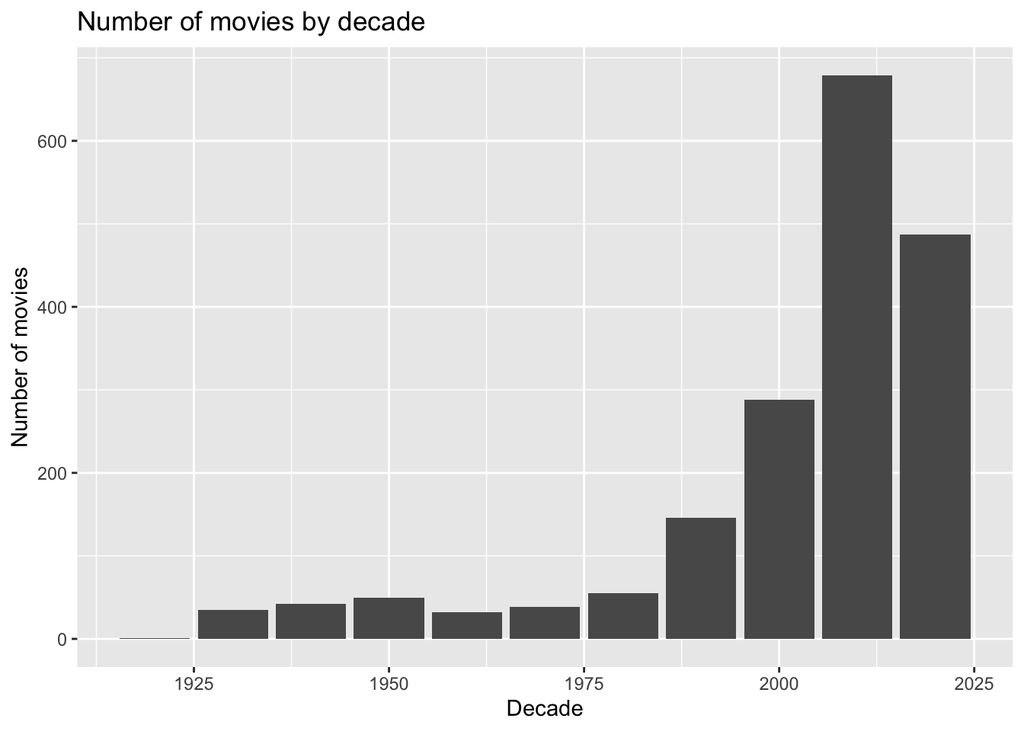

```r
library(ggplot2)
titles <- titles %>% mutate(decade = floor(release_year / 10) * 10)
decade_counts <- titles %>% group_by(decade) %>% summarize(count = n())
ggplot(data = decade_counts, aes(x = decade, y = count)) +
  geom_bar(stat = "identity") +
  labs(title = "Number of movies by decade",
       x = "Decade",
       y = "Number of movies")
```

Next, the top 25 people mentioned in credits:

#Top 25 Mentioned in Credits

```r
credits <- read.csv("credits.csv")
actor_counts <- credits %>%
  select(name) %>%
  group_by(name) %>%
  summarise(count = n()) %>%
  ungroup() %>%
  arrange(desc(count)) %>%
  head(25)
actor_counts
```

```
## # A tibble: 25 × 2
##    name              count
##    <chr>             <int>
##  1 Jim Cummings         61
##  2 Frank Welker         57
##  3 Clarence Nash        49
##  4 Jeff Bennett         48
##  5 Pinto Colvig         47
##  6 Bill Farmer          46
##  7 Walt Disney          42
##  8 Dee Bradley Baker    39
##  9 Corey Burton         37
## 10 Mickie McGowan       37
## # … with 15 more rows
```

And finally, the breakdown of people mentioned in the credits, actors, or directors: #Actors or Directors in Credit Mentions

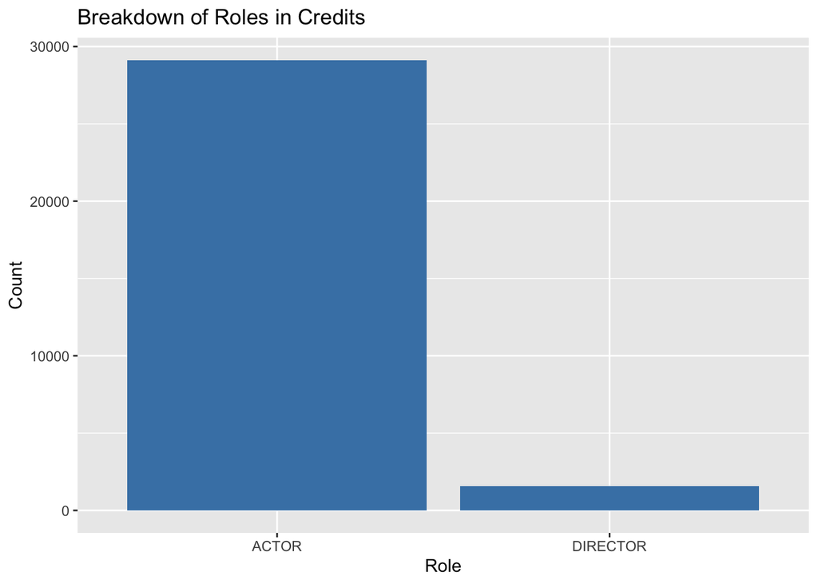

```r
ggplot(credits, aes(x = role)) +
  geom_bar(fill = "steelblue") +
  # theme(axis.text.x = element_text(angle = 45, hjust = 1)) +
  ggtitle("Breakdown of Roles in Credits") +
  xlab("Role") +
  ylab("Count")
```

Conclusion: In this reproducible report, we were able to analyze the data on the Disney+ Movies and TV Shows dataset by Diego Enrique. The code is also version controlled through the following github repository link below. With the analysis provided above through various codes and functions, we were able to learn that The Jonas Brothers: The Concert Experience is the lowest-rated movie according to its IMDB score of 1.6 and the highest-rated title is Bluey with a high score of 9.5, which is accurate of its current fan base and popularity. The random movie generator worked and provided a different movie recommendation every time it ran. Massive spikes of movies per decade appeared post-2000s, once again reflecting both Disney’s history and cartoon/movie/tv show popularity and demand. The highest mention in credits goes to Jim Cummings with 61 mentions in different movies or tv shows. The breakdown of credits whether it is an actor or director indicates that there are more actors than directors amongst all Disney media, which makes sense because you need more actors than directors per show or movie.

Using RStudio and the dataset, one can also reproduce the analysis as performed above and gain similar insights into Disney+ or conduct their own research to find out which movie was most popular in a year maybe they were born or see how low the Jonas Brothers: The Concert Experience actually compares to others or even further compare it to other Jonas Brother shows or movies.

Link to Repository: https://github.com/nstepien20223/step2023